# POLS 3604

Lecture 17 | Congress and the President

## Plan for Today

- Discuss the president’s effectiveness in the legislative arena

## Are Presidents Effective in the Legislative Arena?

- Agenda setting
  - Presidents are able to make legislative proposals directly to Congress
  - Generally, this occurs right after inauguration
- The president is mildly successful in getting their proposals to receive some type of action from Congress
  - Modern studies suggest that approximately one-third of the significant legislation that congress considers is proposed by the president

## What Impacts a Presidents Success in Congress?

- Divided Government
- Polarization
- War
- Divided Government
  - When at least one chamber of Congress and the president are controlled by different parties
- During unified government, a president can rely on co-partisans to introduce the president’s proposals
  - Additionally, they have more members to vote for these proposals
- During divided government, presidents will not receive the support they need to have their proposals achieve success

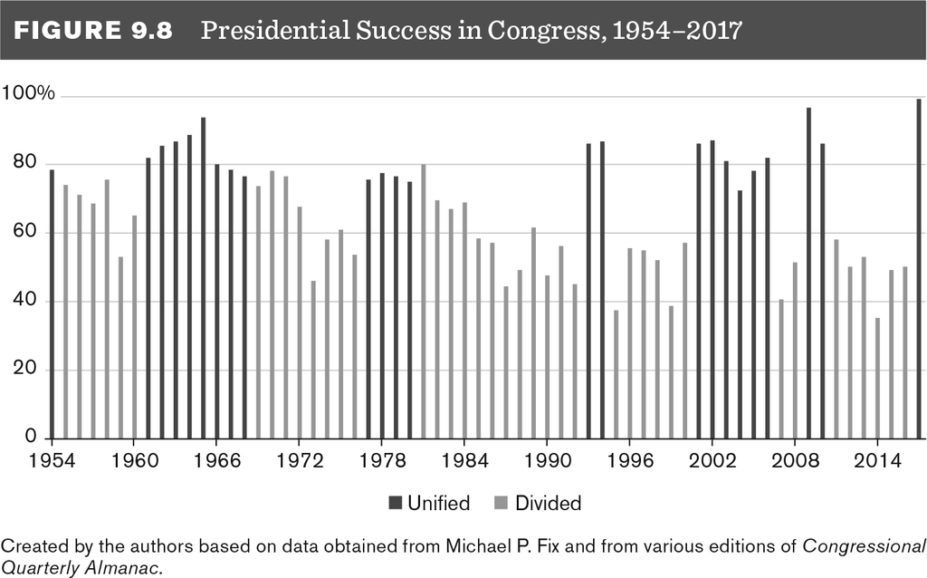

- Polarization
  - Closely related to divided government
  - Recall, ideology and partisanship are not the same thing
- Party polarization and divided government combine to make it increasing difficult for presidents to get their agenda considered in Congress
- If polarization, or the distance between the two parties, is small, the presidents might even be able to overcome divided government
- Veto threats increase during periods of high polarization
- Going public does not work as well during high polarization

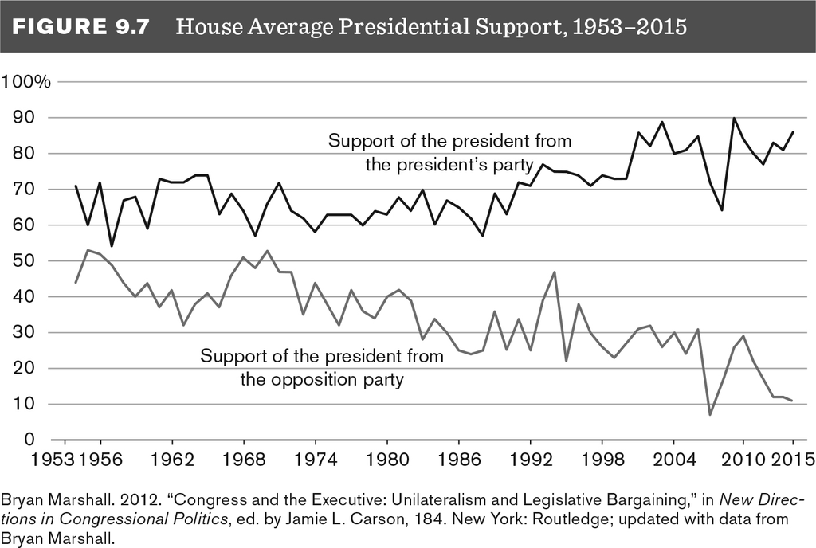

- War
  - Rally around the flag
- During times of war, members of Congress become more deferential to presidents on both foreign and domestic policy
- Presidents are especially given wide latitude in foreign policy
- We have started seeing presidents circumnavigate Congress in certain issues pertaining to war / foreign policy
  - Treaties
    - Obama utilized executive agreements for Iran Nuclear Accord and Paris Climate Agreement

## How does Congress Influence the President?

- Veto override
- Impeachment
  - Article II, Section 4
    - “Shall be removed from Office on Impeachment for, and conviction of, Treason, Bribery, or other High Crimes and Misdemeanors”
      - What does this mean?
      - What is an impeachable offense?

## Final Thoughts

- Presidents have many tools at their disposal to influence the legislative process
- Presidents have increased their role in the legislative process over time

## What Do You Need to Do For Next Class?

- Read Chapter 11 TUSC
- A Major Bill DUE